# **Software Requirements:**

- **Python** (3.6 or later)
- **Necessary libraries:** pandas, numpy, scikit-learn, matplotlib (install using pip install pandas numpy scikit-learn matplotlib)

## **Data Acquisition**

Publicly available dataset from the OpenML Repository's Heart Disease dataset (https://www.openml.org/search?type=data&sort=runs&id=43823&status=active).

# **1. Import Modules for Data Analysis and Load Data:**

```python
import pandas as pd
import numpy as np
import matplotlib.pyplot as plt
import sklearn as skl
## loading data into a variable
data = pd.read_csv("HEART DISEASE PREDICTION USING LOGISTIC REGRESSION.csv")
```

# **2. Data Exploration and Preprocessing:**

### *Get basic information about data:*

```python
print(data.head())  ## View the first few rows
print(data.info())  ## Check data types and missing values
```

```
   Age  Sex  Chest_pain_type   BP  Cholesterol  FBS_over_120  EKG_results  \
0   70    1                4  130          322             0            2
1   67    0                3  115          564             0            2
2   57    1                2  124          261             0            0
3   64    1                4  128          263             0            0
4   74    0                2  120          269             0            2

   Max_HR  Exercise_angina  ST_depression  Slope_of_ST  \
0     109                0            2.4            2
1     160                0            1.6            2
2     141                0            0.3            1
3     105                1            0.2            2
4     121                1            0.2            1

   Number_of_vessels_fluro  Thallium Heart_Disease
0                        3         3      Presence
1                        0         7       Absence
2                        0         7      Presence
3                        1         7       Absence
4                        1         3       Absence
<class 'pandas.core.frame.DataFrame'>
RangeIndex: 270 entries, 0 to 269
Data columns (total 14 columns):
 #   Column                   Non-Null Count  Dtype
---  ------                   --------------  -----
 0   Age                      270 non-null    int64
 1   Sex                      270 non-null    int64
 2   Chest_pain_type          270 non-null    int64
 3   BP                       270 non-null    int64
 4   Cholesterol              270 non-null    int64
 5   FBS_over_120             270 non-null    int64
 6   EKG_results              270 non-null    int64
 7   Max_HR                   270 non-null    int64
 8   Exercise_angina          270 non-null    int64
 9   ST_depression            270 non-null    float64
 10  Slope_of_ST              270 non-null    int64
 11  Number_of_vessels_fluro  270 non-null    int64
 12  Thallium                 270 non-null    int64
 13  Heart_Disease            270 non-null    object
dtypes: float64(1), int64(12), object(1)
memory usage: 29.7+ KB
None
```

- **head():** Displays the first few rows of the data.
- **info():** Provides information about data types and missing values.

### *Handle missing values: (Imputation techniques or removal of missingness)*

```python
data = data.dropna()  ## Remove rows with missing values
```

### *Preparing featureset for the training purpose*

```python
## checking features of the dataset
data.columns
```

```
Index(['Age', 'Sex', 'Chest_pain_type', 'BP', 'Cholesterol', 'FBS_over_120',
       'EKG_results', 'Max_HR', 'Exercise_angina', 'ST_depression',
       'Slope_of_ST', 'Number_of_vessels_fluro', 'Thallium', 'Heart_Disease'],
      dtype='object')
```

```python
## storing input data into a variable
input_featureset = data.drop(['Age', 'Sex', 'Heart_Disease'], axis=1).values
```

```python
## target variable
output_featureset = data.iloc[:, 13].values
```

### *Feature scaling: (standardization)*

```python
from sklearn.preprocessing import StandardScaler
```

```python
### making object of the StandardScaler
scalar = StandardScaler()
```

```python
scaled = scalar.fit_transform(input_featureset)
```

- **StandardScaler:** Standardizes features by removing the mean and scaling to unit variance.
- **fit_transform:** Fits the scalar and transforms the data.

### *Encode categorical features:*

```python
from sklearn.preprocessing import LabelEncoder
```

```python
le = LabelEncoder()
```

```python
labelled = le.fit_transform(data['Heart_Disease'])
```

```python
# Combine scaled features with target variable
data_prepared = pd.DataFrame(scaled, columns=data.columns[:-3])
data_prepared['Heart_Disease'] = labelled
```

- **LabelEncoder:** Converts categorical labels into numerical values.
- **fit_transform:** Fits the encoder to the data and transforms the column.

# **3. Split Data into Training and Testing Sets:**

```python
X = data_prepared.drop(["Heart_Disease", "Sex"], axis=1) ## axis=1 means column and axis=0 means row independently
y = data_prepared["Heart_Disease"]  ## Target variable

from sklearn.model_selection import train_test_split
X_train, X_test, y_train, y_test = train_test_split(X, y, test_size=0.05, random_state=42)
```

# **4. Train the Logistic Regression Model:**

```python
from sklearn.linear_model import LogisticRegression

model = LogisticRegression()
model.fit(X_train, y_train)
```

```
LogisticRegression()
```

- **LogisticRegression:** Creates a logistic regression classifier object.
- **fit:** Trains the model on the training data.

# **5. Evaluate the Model:**

```
Confusion matrix is:
 [[9 0]
 [0 5]]


Evaluation metrics of the model is:
 Accuracy: 1.0 	Precision: 1.0 	Recall: 1.0 	F1 Score: 1.0
```

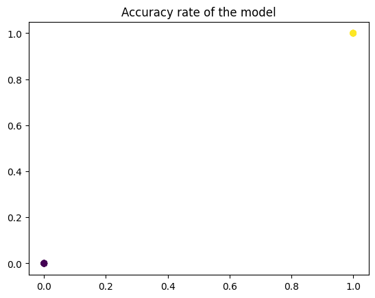

```python
from sklearn.metrics import accuracy_score, precision_score, recall_score, f1_score, confusion_matrix

## Make predictions on the testing set
y_pred = model.predict(X_test)

## printing the confusion matrix
print('Confusion matrix is:\n', confusion_matrix(y_test, y_pred));print('\n')

## visualizing the accuracy of the model
plt.title('Accuracy rate of the model')
plt.scatter(y_test, y_pred, c=y_pred)

## Calculate evaluation metrics
accuracy = accuracy_score(y_test, y_pred)
precision = precision_score(y_test, y_pred)
recall = recall_score(y_test, y_pred)
f1 = f1_score(y_test, y_pred)

print('Evaluation metrics of the model is:\n', "Accuracy:", accuracy, "\tPrecision:", precision, "\tRecall:", recall, "\tF1 Score:", f1);print('\n')
```

1. **Import Metrics:**
- from sklearn.metrics import accuracy_score, precision_score, recall_score, f1_score: This line imports the necessary functions from the sklearn.metrics module to calculate various evaluation metrics for classification models.
2. **Prediction:**
- y_pred = model.predict(X_test): This line uses the trained logistic regression model (model) to make predictions on the unseen testing data (X_test). The predicted labels are stored in the y_pred variable.
3. **Evaluation Metrics Calculation:**
- accuracy = accuracy_score(y_test, y_pred): Calculates the accuracy, which is the proportion of correct predictions made by the model.
- precision = precision_score(y_test, y_pred): Calculates the precision, which is the ratio of true positives (correctly predicted positive cases) to all predicted positive cases. It measures how well the model identifies actual positives.
- recall = recall_score(y_test, y_pred): Calculates the recall, which is the ratio of true positives to all actual positive cases. It measures how well the model finds all the actual positives.
- f1 = f1_score(y_test, y_pred): Calculates the F1 score, which is the harmonic mean of precision and recall. It provides a balance between the two metrics.
4. **Printing Results:**
- The calculated metrics (accuracy, precision, recall, F1 score) are printed to the console along with descriptive labels.